# Stock Price Analysis Using Yahoo Finance

Data from Webscraping

Author

Levi Sayles

# Explanation

# Libraries

- **tidyverse**: A collection of R packages designed for data science. It includes packages like `ggplot2` for data visualization, `dplyr` for data manipulation, and `readr` for reading data.
- **quantmod**: A package for financial modeling that allows for easy retrieval of stock data from various sources, including Yahoo Finance.
- **knitr**: A package that is used for dynamic report generation in R, making it easier to embed R code and output in documents.
- **ggplot2**: A part of the tidyverse, `ggplot2` is a popular package for creating visualizations in R, using a grammar of graphics approach.

# 1. Introduction

In this report, we investigate the question: *“How do the stock prices of major technology companies vary over time, and what insights can we derive regarding their price volatility?”* This analysis aims to identify trends in the stock prices of major tech companies, providing insights into their performance in recent market conditions.

# 2. Data Collection Strategy

The data was collected using the `quantmod` package to retrieve historical stock price data from Yahoo Finance. The selected companies for this analysis are:

- **Apple (AAPL)**
- **Microsoft (MSFT)**
- **Google (GOOGL)**
- **Amazon (AMZN)**

The data includes key variables such as:

- **Date**
- **Open Price**
- **High Price**
- **Low Price**
- **Close Price**
- **Volume**
- **Adjusted Close Price**

The function iterates through the tickers of the selected companies to ensure a comprehensive dataset.

# 3. Data Wrangling

We start by importing the dataset saved locally or from a cloud storage.

The data wrangling process involves cleaning and transforming the raw data into a format suitable for analysis. This includes filtering out any missing or irrelevant data and creating summary statistics for each company.

1. **Data Cleaning**: The first step is to import the dataset and remove any rows with missing values in the `Close` column. This ensures that our analysis is based on complete data points.
2. **Data Transformation**: We convert the `Date` column to a date format for easy plotting and further analysis.
3. **Grouping and Summarizing**: We then group the data by `Company` and calculate summary statistics, such as the average closing price (`Average_Close`), maximum closing price (`Max_Close`), minimum closing price (`Min_Close`), and the total count of observations (`Count`). These summary statistics help provide an overview of each company’s stock performance over the selected time period.

# 4. Analysis and Visualizations

#### 4.1 Average Closing Price by Company

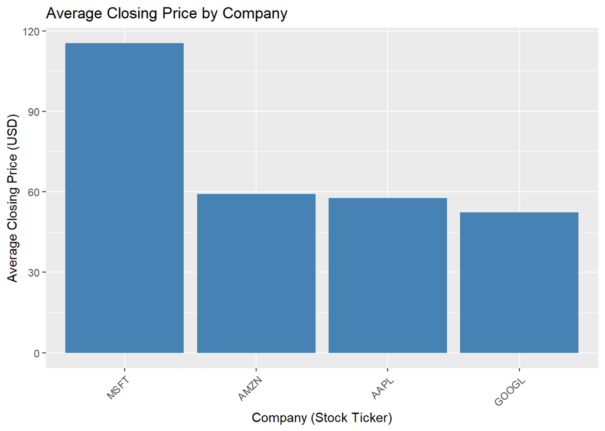

#### 4.2 Closing Price Over Time

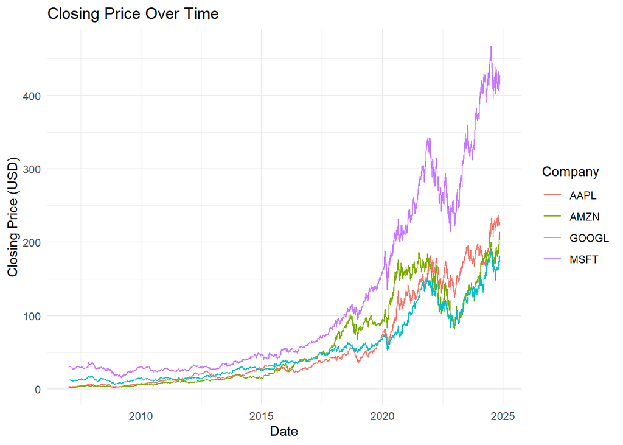

The line plot of closing prices over time reveals the temporal trends in the stock prices for each company. For instance, we can identify any particular upward or downward movements in the stocks and assess how each company responds to market conditions. This graph is useful for observing patterns like seasonality or trends caused by significant events (e.g., product launches or earnings reports).

#### 4.3 Distribution of Daily Price Range by Company

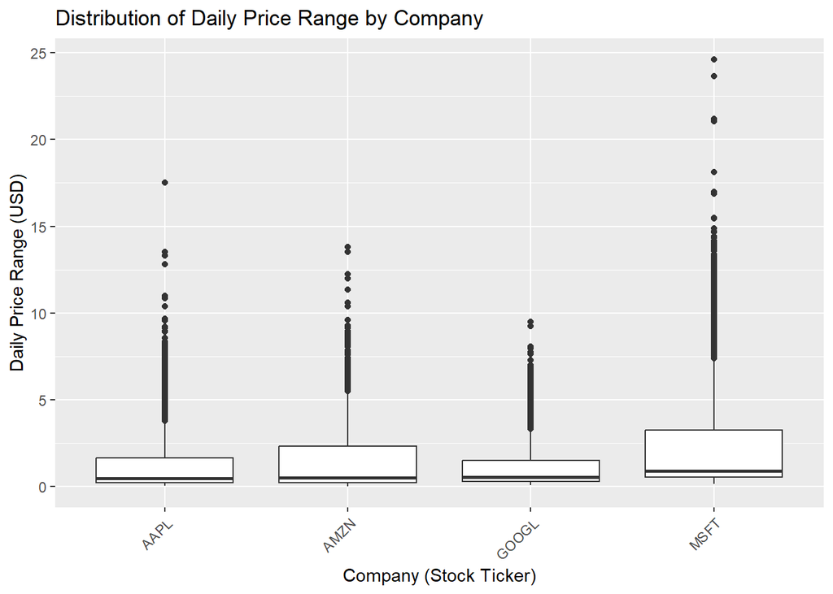

#### 4.4 Trading Volume Distribution

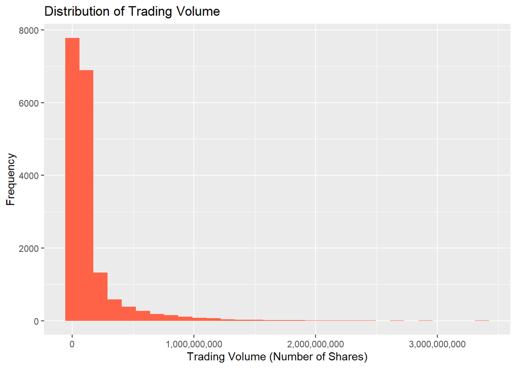

The histogram of trading volumes provides insights into investor interest in these stocks. High trading volume indicates significant market activity, suggesting that many investors are buying or selling the stock. This insight can be useful for liquidity assessment, as highly traded stocks are typically easier to buy or sell without affecting the price.

#### 4.5 Summary Table

Summary of Stock Prices by Company

| Company | Average_Close | Max_Close | Min_Close | Count |
| --- | --- | --- | --- | --- |
| AAPL | 57.71344 | 236.48 | 2.792857 | 4500 |
| AMZN | 59.09479 | 214.10 | 1.751500 | 4500 |
| GOOGL | 52.32749 | 191.18 | 6.442442 | 4500 |
| MSFT | 115.36850 | 467.56 | 15.150000 | 4500 |

The summary table provides an overview of the average, maximum, and minimum closing prices for each company, along with the number of data points collected. This gives investors a reference point for understanding both the highest highs and lowest lows of each company, helping in making informed decisions regarding investment